# 2014 Seagrass fish diversity and abundance

Zach Monteith

Wed Feb 24 14:36:31 2016

# Fish diversity and abundance

## Setup

Remove all objects for a clean start!

**NOTE:** this command will clear all your objects, don’t run it if you have any unsaved objects you would like to keep.

**NOTE2:** this command should only be used when running this script directly; if you are sourcing multiple scripts including this one, make sure this is commented out, otherwise it will cause problems!

```r
rm(list = ls())
```

Next, install packages that will be used for this script. Note that this command is currently commented out, if you do not have these packages, make sure you remove the hash and install them!

```r
# install.packages(c("ggplot2", "dplyr", "magrittr))
```

Now the packages are install, make sure to load them

```r
lapply(c("ggplot2", "dplyr", "magrittr"), library, character.only = T)
```

This script uses functions that are stored in a separate script, so we’ll source that now.

```r
source("fish.functions.R")
```

Now we’re ready to load the fish data.

**NOTE:** Make sure you change the path to match where you have your csv’s stored, otherwise this won’t work!

```r
fish <- read.csv("/Users/Zach/Google Drive/Hakai SEA 2014/R files/csv files/Fish.csv", header = T)
```

Now have quick check of the data structure and format

```r
glimpse(fish)  # glimpse() is similar to str(), but with cleaner format
```

```
## Observations: 6,609
## Variables: 13
## $ Date       (fctr) 23/07/2014, 23/07/2014, 23/07/2014, 23/07/2014, 23...
## $ Site       (fctr) Lower_Choked, Lower_Choked, Lower_Choked, Lower_Ch...
## $ Site_ID    (fctr) LC, LC, LC, LC, LC, LC, LC, LC, LC, LC, LC, LC, LC...
## $ Diver      (fctr) RW, RW, RW, RW, RW, RW, RW, RW, RW, RW, RW, MHL, M...
## $ Mode       (fctr) SCUBA, SCUBA, SCUBA, SCUBA, SCUBA, SCUBA, SCUBA, S...
## $ Transect   (fctr) 1, 1, 2, 2, 2, 2, 2, 2, 2, 3, 3, 1, 1, 1, 1, 1, 1,...
## $ Depth_m    (dbl) 2.6, 2.6, 3.6, 3.6, 3.6, 3.6, 3.6, 3.6, 3.6, 3.2, 3...
## $ Time_Start (fctr) 9:31:00AM, 9:31:00AM, 10:08:00AM, 10:08:00AM, 10:0...
## $ Species    (fctr) Hexagrammos_decagrammus, Sebastes_maliger, Hexagra...
## $ Common     (fctr) Kelp_Greenling, Quillback, Kelp_Greenling, Kelp_Gr...
## $ Length_cm  (int) 28, 20, 26, 20, 14, 10, 8, 10, 9, 16, 7, 15, 10, 10...
## $ Estimate   (int) 1, 1, 1, 1, 1, 1, 1, 1, 1, 1, 1, 1, 1, 1, 1, 1, 1, ...
## $ Notes      (fctr) , , , , , , , , , , , , , , , , , , , , , , , ,
```

```r
head(fish)
```

```
##         Date         Site Site_ID Diver  Mode Transect Depth_m Time_Start
## 1 23/07/2014 Lower_Choked      LC    RW SCUBA        1     2.6  9:31:00AM
## 2 23/07/2014 Lower_Choked      LC    RW SCUBA        1     2.6  9:31:00AM
## 3 23/07/2014 Lower_Choked      LC    RW SCUBA        2     3.6 10:08:00AM
## 4 23/07/2014 Lower_Choked      LC    RW SCUBA        2     3.6 10:08:00AM
## 5 23/07/2014 Lower_Choked      LC    RW SCUBA        2     3.6 10:08:00AM
## 6 23/07/2014 Lower_Choked      LC    RW SCUBA        2     3.6 10:08:00AM
##                   Species         Common Length_cm Estimate Notes
## 1 Hexagrammos_decagrammus Kelp_Greenling        28        1
## 2        Sebastes_maliger      Quillback        20        1
## 3 Hexagrammos_decagrammus Kelp_Greenling        26        1
## 4 Hexagrammos_decagrammus Kelp_Greenling        20        1
## 5        Sebastes_maliger      Quillback        14        1
## 6  Cymatogaster_aggregata   Shiner_perch        10        1
```

## Formatting

Before getting to the data summary and figure making stages, we’ll need to do some cleaning of formatting to make sure things are consistent with the other datasets. Here we’ll also definite taxonomic subsets of the data to use later on.

### Renaming and adding factors

```r
fish <- fish %>%
  mutate(transect = Transect,
         Transect = Time_Start,
         site_id = as.factor(ifelse(Site_ID == "SC", "CS",
                                    ifelse(Site_ID == "LC", "CL",
                                           ifelse(Site_ID == "NT", "TN",
                                                  as.character(Site_ID))))),
         site    = ifelse(site_id == "CS", "Choked Sandspit",
                          ifelse(site_id == "CL", "Choked Lower",
                                 ifelse(site_id == "TB", "Triquet Bay",
                                        ifelse(site_id == "TN", "Triquet North",
                                               ifelse(site_id == "TB", "Triquet Bay",
                                                      ifelse(site_id == "GW", "Goose Southwest",
                                                             ifelse(site_id == "GE", "Goose Southeast",
                                                                    ifelse(site_id == "MS", "McMullin South",
                                                                           ifelse(site_id == "MN", "McMullin North",
                                                                                  NA))))))))),
         region  = as.factor(ifelse(site_id == "CS" | site_id == "CL", "Choked",
                                   ifelse(site_id == "TB" | site_id == "TN", "Triquet",
                                          ifelse(site_id == "GE" | site_id == "GW", "Goose",
                                                 "McMullin")))),
         Common = ifelse(Common == "Black_rockfish", "black rockfish",
                         ifelse(Common == "Cabezon", "cabezon",
                                ifelse(Common == "Copper_rockfish", "copper rockfish",
                                       ifelse(Common == "Cresent_gunnel", "cresent gunnel",
                                              ifelse(Common == "Greenling", "unknown greenling",
                                                     ifelse(Common == "Gunnel", "unknown gunnel",
                                                            ifelse(Common == "Juvenile_Perch" | Common == "Perch", "unknown perch",
                                                                   ifelse(Common == "Juvenile_Rockfish", "unknown rockfish",
                                                                          ifelse(Common == "Kelp_Greenling", "kelp greenling",
                                                                                 ifelse(Common == "Kelp_perch", "kelp perch",
                                                                                        ifelse(Common == "Pacific_herring", "pacific herring",
                                                                                               ifelse(Common == "Quillback", "quillback rockfish",
                                                                                                      ifelse(Common == "Red_Irish_Lord", "red irish lord",
                                                                                                             ifelse(Common == "Sanddab", "unknown sanddab",
                                                                                                                    ifelse(Common == "Sandlance", "sandlance",
                                                                                                                           ifelse(Common == "Sculpin", "unknown sculpin",
                                                                                                                                  ifelse(Common == "Shiner_perch", "shiner perch",
                                                                                                                                         ifelse(Common == "Starry_Flounder", "starry flounder",
                                                                                                                                                ifelse(Common == "Striped_perch", "striped perch",
                                                                                                                                                       ifelse(Common == "Tubesnout", "tubesnout",
                                                                                                                                                              ifelse(Common == "Whitespotted_greenling", "white-spotted greenling",
                                                                                                                                                                     NA)))))))))))))))))))))) %>%
  subset(Mode %in% "SCUBA")  # select only SCUBA surveys
```

### Adding absences

This section is for adding in absence data. Currently, survey data only record species that are observed, while unobserved species are implicitly absent. However, in order for average fish (or fish species) per transect to not be conditional on presence, the absences must be explicit. The following code chunk below checks each transect for each fish species, and when they are absent, adds an entry with a zero count.

```r
# Create fish species, and site variables first
fish.spp <- subset(unique(fish$Common), !grepl("unknown", unique(fish$Common)))
fish.sites <- unique(fish$site)
fish$unique.tran <- as.factor(with(fish, paste(site, Transect, Diver, sep = "::")))
unique.tran <- unique(fish$unique.tran)

# for each site...
for (i in 1:length(unique.tran)) {
  tmp.fish.tran <-
    subset(fish, unique.tran %in% unique.tran[i])

  tmp.metadata <-
    tmp.fish.tran %>%
    group_by(Date, Site, Site_ID, Diver, Mode, Transect, Depth_m, Time_Start,
             site_id, site, region, transect, unique.tran) %>%
    # group_by(year, day, region, site, site_id, Transect, survey, diver, mode,
    #          tran_length, tran_type, time_start, time_end, tide_start,
    #          tide_end, vis_ft, current_cat, depth_m, unique.tran) %>%
    summarise()

  tmp.metadata$Common    <- NA
  tmp.metadata$Species   <- NA
  tmp.metadata$Length_cm <- NA
  tmp.metadata$Estimate  <- 0
  tmp.metadata$Notes     <- "implicit zero"

  # for each fish species...
  for (j in 1:length(fish.spp)) {
    # if fish species j does not show up in any row, add new row
    if (length(grep(fish.spp[j], tmp.fish.tran$Common)) == 0) {
      tmp.metadata$Common <- fish.spp[j]
      fish <- rbind(fish, tmp.metadata)
      } else { # if fish species j is present, move on
        next
    }
  }
}
```

### Defining taxonomic subsets

Here we’ll subset the fish dataset into a couple smaller groups of interest, rockfish and flatfish, for a more indepth look.

```r
fish.noschool  <- subset(fish, !grepl("herring|lance|perch|tubesnout", fish$Common))

fish.rock      <- subset(fish, grepl("rockfish", fish$Common))

fish.flat      <- subset(fish, grepl("sanddab|flounder|sole", fish$Common))

fish.schooling <- subset(fish, grepl("herring|lance|perch|tubesnout", fish$Common))
```

## Frequency table

Now that all the `site_id`’s are formatted correctly, this is a good time to generate a frequency table. This will give a nice overview of how many of each species were observed, and where. * NOTE: currently under construction, refers to observations rather than counts *

```r
(fish.count <- table(fish$Common, fish$site_id))
```

```
##
##                       CL  CS  GE  GW  MN  MS  TB  TN
##   black rockfish       6   1   0   0   3   2   4  34
##   cabezon              6   1   0   0   0   0   1   0
##   copper rockfish      6   0   1   2   0   3   1   1
##   cresent gunnel       6   0   0   0   0   1   1   0
##   kelp greenling       8   1  11   5   0   0   1   2
##   kelp perch           6   0   0   2   1   0   1   1
##   quillback rockfish   6   0   0   0   0   0   1   0
##   red irish lord       6   0   1   0   0   0   1   0
##   shiner perch        13   1 102   0  97  32  21  64
##   striped perch        6   1   1   0   0   0   1   1
##   unknown gunnel       1   2   0   0   0   0   0   0
##   unknown perch        0   0   0   0   0   0  30 110
##   unknown rockfish     0   7   0   2   2   0   0  82
##   unknown sanddab      1   0   0   0   0   0   0   0
```

Now save the table for later use

```r
write.csv(fish.count, "Fish_Summary.csv")
```

## Summaries

This section will calculate abundance, richness, and diversity (using H`, the [Shannon Index](https://en.wikipedia.org/wiki/Diversity_index#Shannon_index)), by site, and by region. This is done first for all fish, then for the two taxonomic subsets we specified earlier: rockfish, and flat fish. Figures of the same summary data will follow directyl after.

### All fish

```r
(fish.summary.site     <- MakeFishSummary(fish, site))
```

```
##     region            site mean.abund   se.abund mean.H.prime se.H.prime n
## 1   Choked    Choked Lower   3.833333  0.9098229    0.7542372 0.08669932 6
## 2   Choked Choked Sandspit   4.666667  1.6666667    0.7039655 0.21108946 3
## 3    Goose Goose Southeast  38.666667 15.6240555    0.6413083 0.41783183 3
## 4    Goose Goose Southwest   3.666667  1.3333333    0.6683969 0.33556107 3
## 5 McMullin  McMullin North  34.333333 17.0326484    0.3385743 0.09838419 3
## 6 McMullin  McMullin South  12.666667  9.6838927    0.6555532 0.23340981 3
## 7  Triquet     Triquet Bay  18.333333  8.8380491    0.3788397 0.19101029 3
## 8  Triquet   Triquet North  98.333333 76.8338756    1.2810249 0.10639112 3
##   rich
## 1    6
## 2    7
## 3    5
## 4    4
## 5    4
## 6    4
## 7    3
## 8    8
```

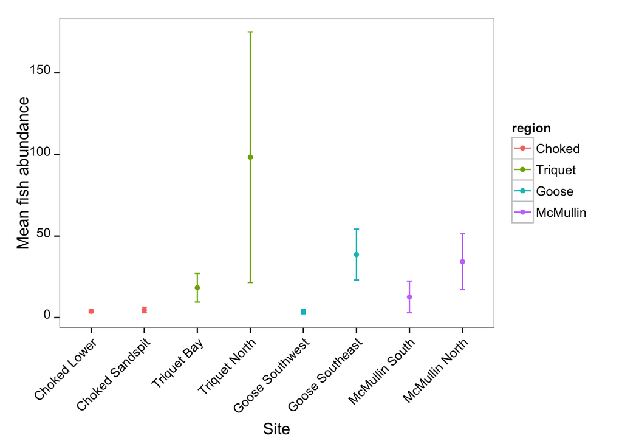

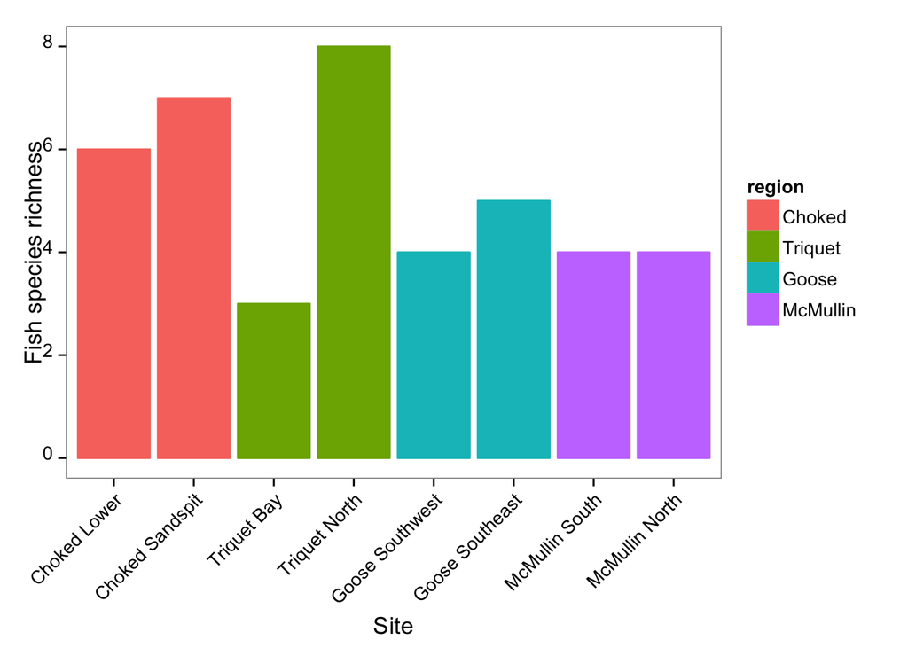

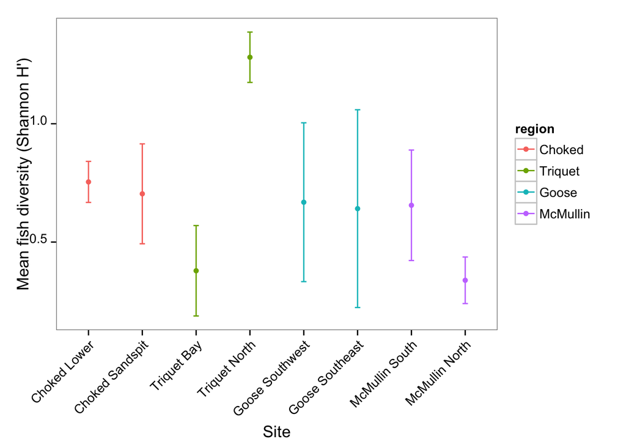

```r
write.csv(fish.summary.site, "summaries/fish.abund.site.2014.csv")
(fish.figs.site        <- MakeFishFigures(fish.summary.site))
```

```r
(fish.summary.region   <- MakeFishSummary(fish))
```

```
##     region mean.abund   se.abund mean.H.prime se.H.prime n rich
## 1   Choked   4.111111  0.7718024    0.7374800  0.0831590 9    9
## 2    Goose  21.166667 10.5084622    0.6548526  0.2397366 6    7
## 3 McMullin  23.500000 10.0124922    0.4970638  0.1336252 6    6
## 4  Triquet  58.333333 38.9398396    0.8299323  0.2241823 6    8
```

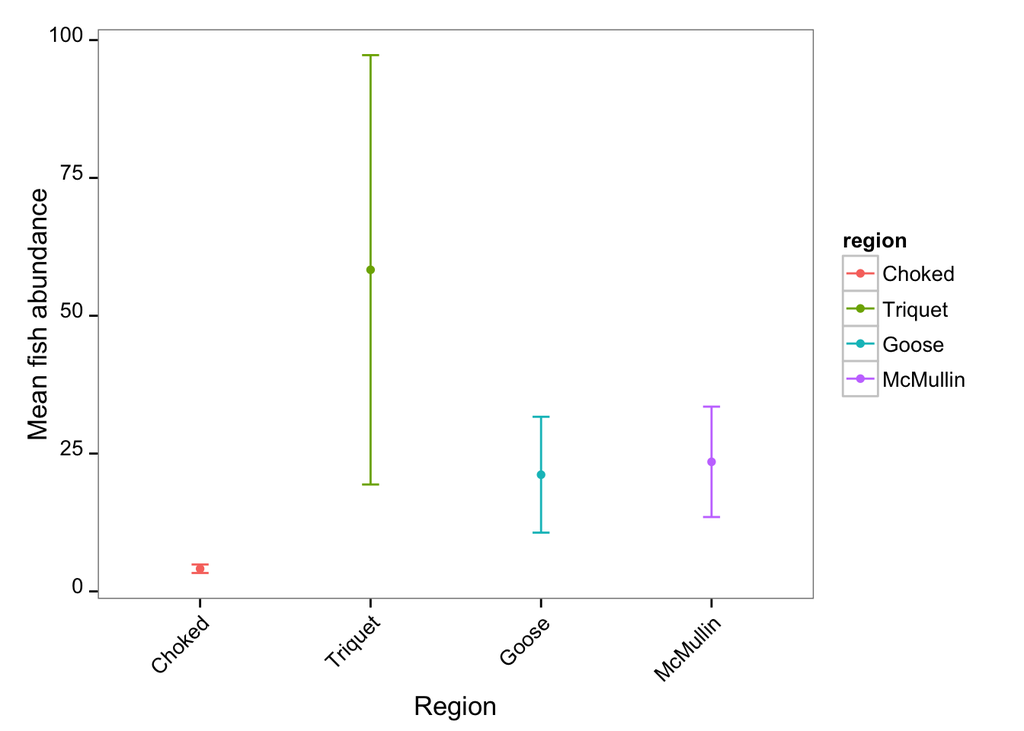

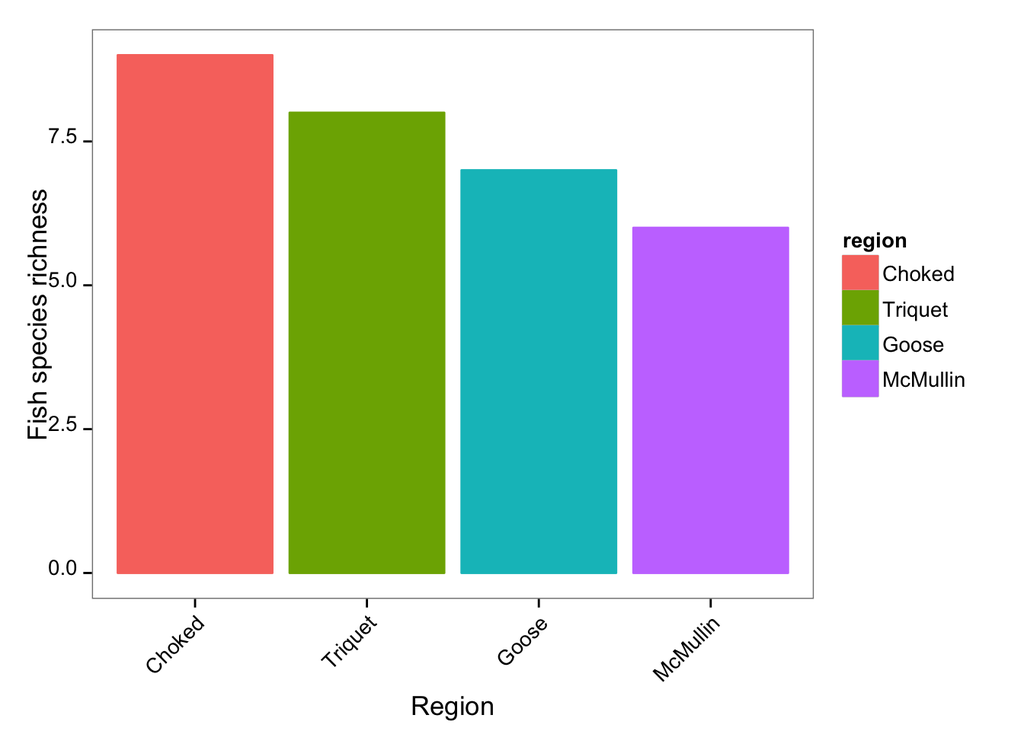

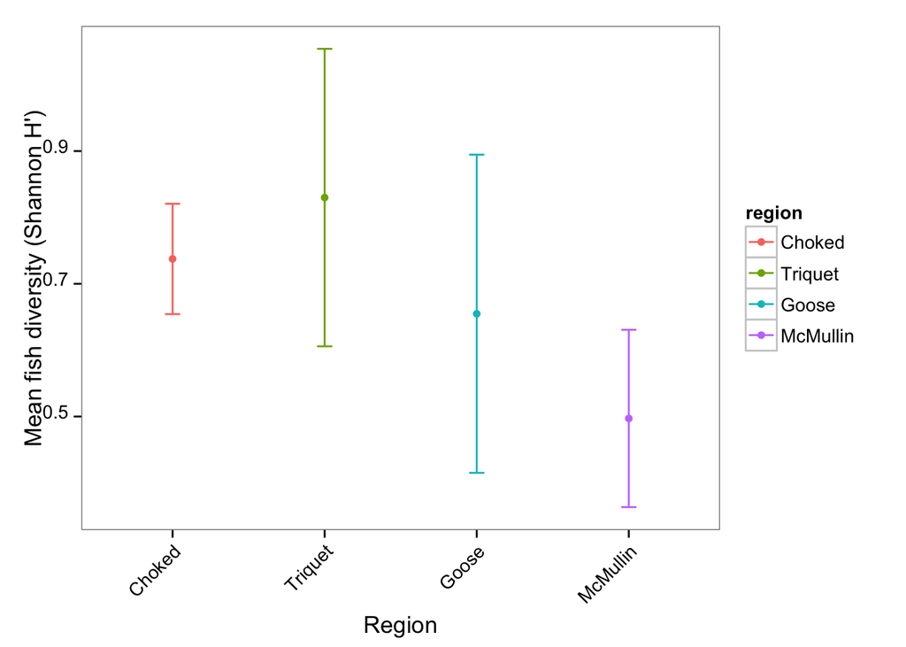

```r
write.csv(fish.summary.region, "summaries/fish.abund.region.2014.csv")
(fish.figs.region      <- MakeFishFigures(fish.summary.region))
```

### All fish, schoolers excluded

```r
(fishnoschool.summary.site    <- MakeFishSummary(fish.noschool, site))
```

```
##     region            site mean.abund   se.abund mean.H.prime se.H.prime n
## 1   Choked    Choked Lower   2.166667  0.3073181    0.5587450 0.11232155 6
## 2   Choked Choked Sandspit   4.000000  2.0000000    0.3566391 0.20034736 3
## 3    Goose Goose Southeast   4.333333  1.7638342    0.3167568 0.31675685 3
## 4    Goose Goose Southwest   3.000000  1.1547005    0.5289282 0.27954402 3
## 5 McMullin  McMullin North   1.666667  0.6666667    0.2121714 0.21217139 3
## 6 McMullin  McMullin South   2.000000  0.5773503    0.2121714 0.21217139 3
## 7  Triquet     Triquet Bay   2.000000  1.0000000    0.0000000 0.00000000 2
## 8  Triquet   Triquet North  39.666667 31.1786964    0.7546021 0.04449143 3
##   rich
## 1    5
## 2    5
## 3    3
## 4    3
## 5    2
## 6    3
## 7    1
## 8    4
```

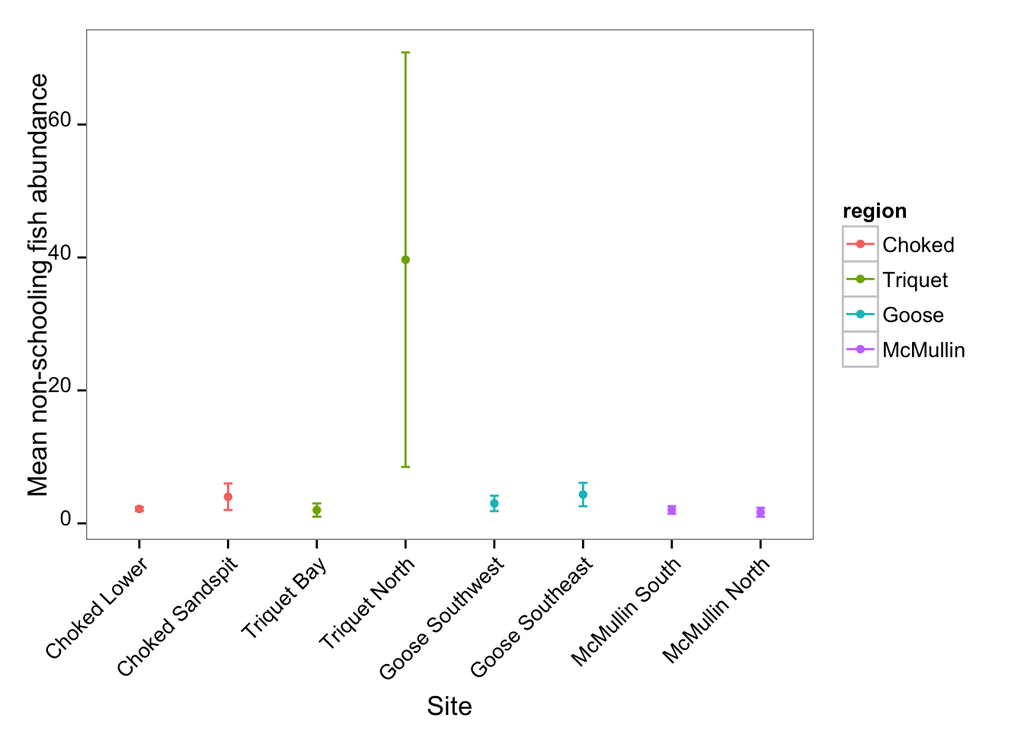

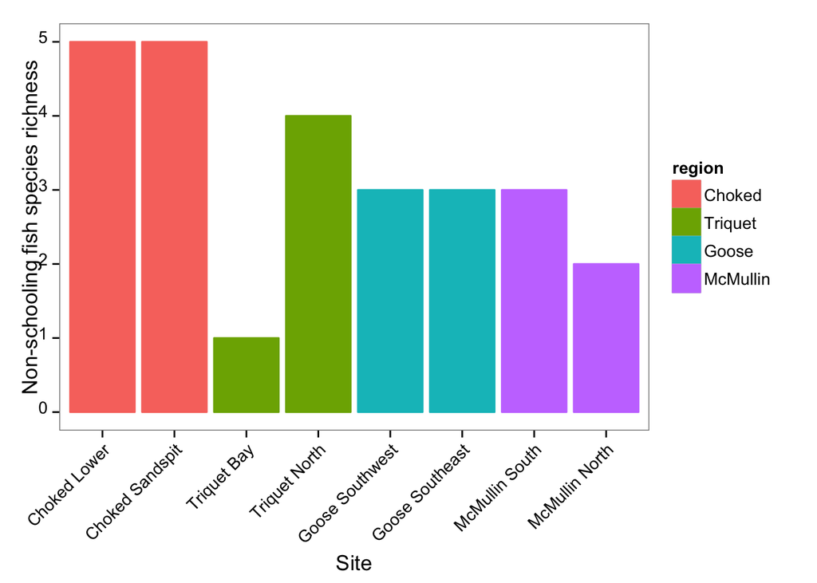

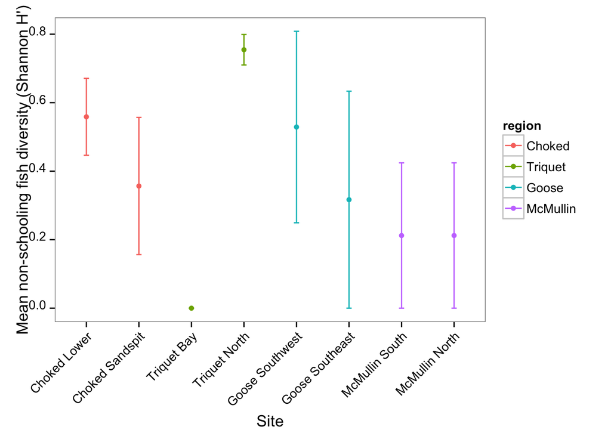

```r
write.csv(fishnoschool.summary.site, "summaries/fish.noschool.abund.site.2014.csv")
(fish.figs.site              <- MakeFishFigures(fishnoschool.summary.site))
```

```r
(fishnoschool.summary.region <- MakeFishSummary(fish.noschool))
```

```
##     region mean.abund   se.abund mean.H.prime se.H.prime n rich
## 1   Choked   2.777778  0.6826781    0.4913764 0.09867257 9    7
## 2    Goose   3.666667  0.9888265    0.4228425 0.19479935 6    4
## 3 McMullin   1.833333  0.4013865    0.2121714 0.13418897 6    4
## 4  Triquet  24.600000 19.4128823    0.4527612 0.18643847 5    4
```

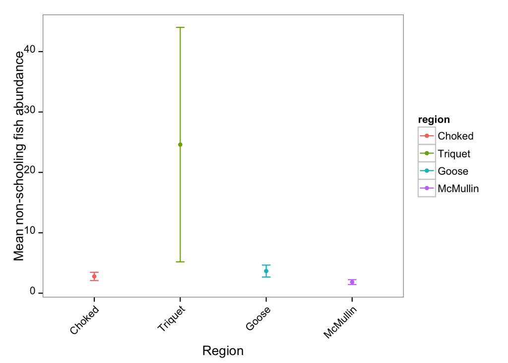

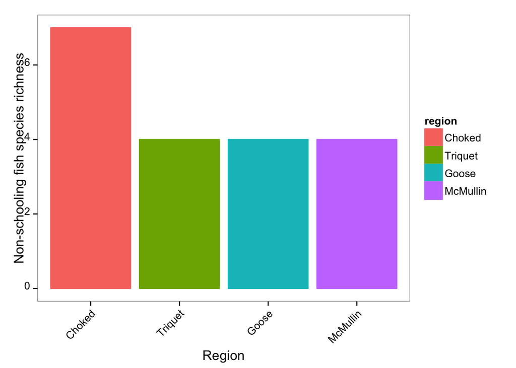

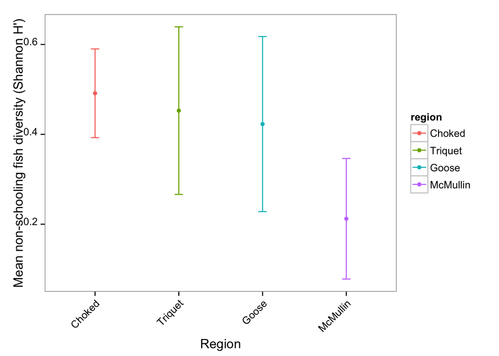

```r
write.csv(fishnoschool.summary.region, "summaries/fish.noschool.abund.region.2014.csv")
(fish.figs.region            <- MakeFishFigures(fishnoschool.summary.region))
```

### Rockfish only

```r
(rockfish.summary.site   <- MakeFishSummary(fish.rock, site))
```

```
##     region            site mean.abund   se.abund mean.H.prime se.H.prime n
## 1   Choked    Choked Lower   1.000000  0.0000000    0.0000000 0.00000000 6
## 2   Choked Choked Sandspit   4.000000  3.0000000    0.0000000 0.00000000 2
## 3    Goose Goose Southeast   1.000000         NA    0.0000000         NA 1
## 4    Goose Goose Southwest   1.333333  0.3333333    0.2310491 0.23104906 3
## 5 McMullin  McMullin North   1.666667  0.6666667    0.2121714 0.21217139 3
## 6 McMullin  McMullin South   2.500000  0.5000000    0.3182571 0.31825708 2
## 7  Triquet     Triquet Bay   2.000000  1.0000000    0.0000000 0.00000000 2
## 8  Triquet   Triquet North  39.000000 31.0053759    0.6475469 0.07850019 3
##   rich
## 1    2
## 2    2
## 3    1
## 4    2
## 5    2
## 6    2
## 7    1
## 8    3
```

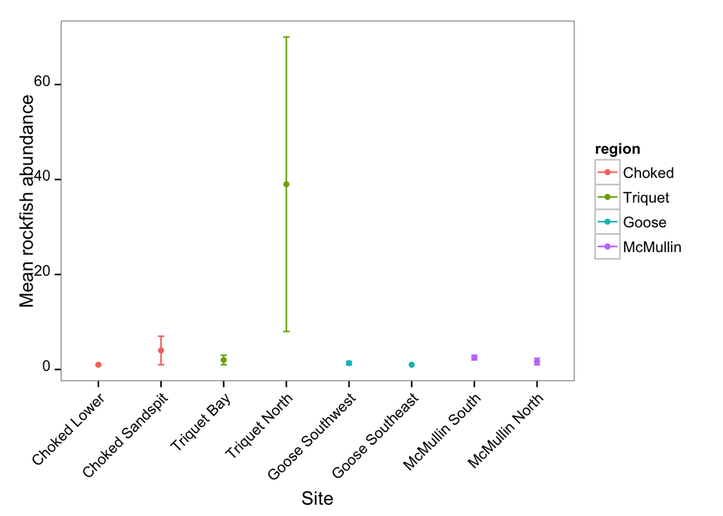

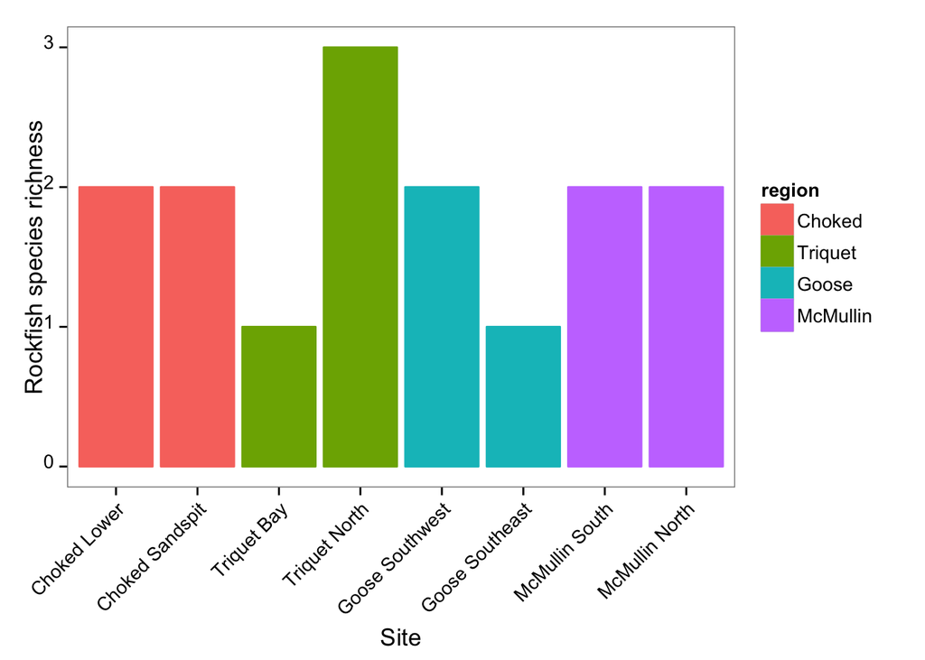

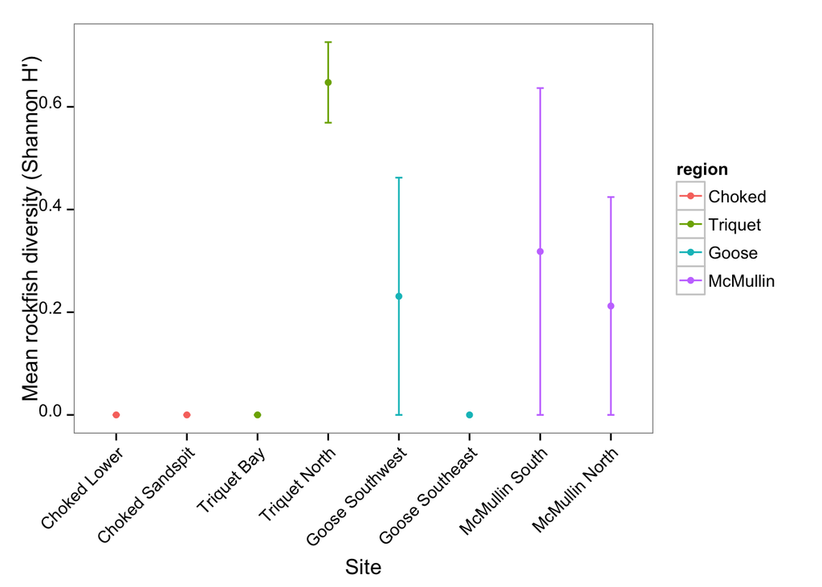

```r
write.csv(rockfish.summary.site, "summaries/rockfish.abund.site.2014.csv")
(rockfish.figs.site      <- MakeFishFigures(rockfish.summary.site))
```

```r
(rockfish.summary.region <- MakeFishSummary(fish.rock))
```

```
##     region mean.abund   se.abund mean.H.prime se.H.prime n rich
## 1   Choked       1.75  0.7500000    0.0000000  0.0000000 8    3
## 2    Goose       1.25  0.2500000    0.1732868  0.1732868 4    2
## 3 McMullin       2.00  0.4472136    0.2546057  0.1559135 5    3
## 4  Triquet      24.20 19.2520129    0.3885281  0.1643402 5    3
```

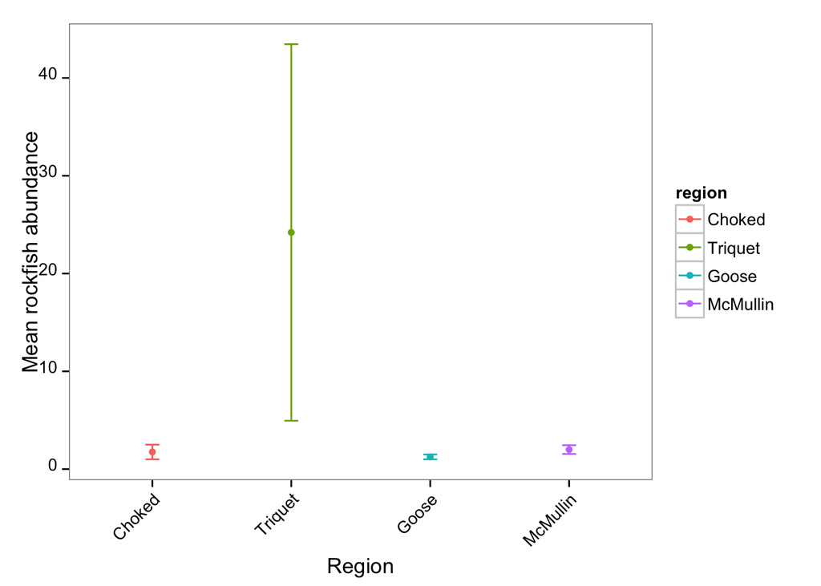

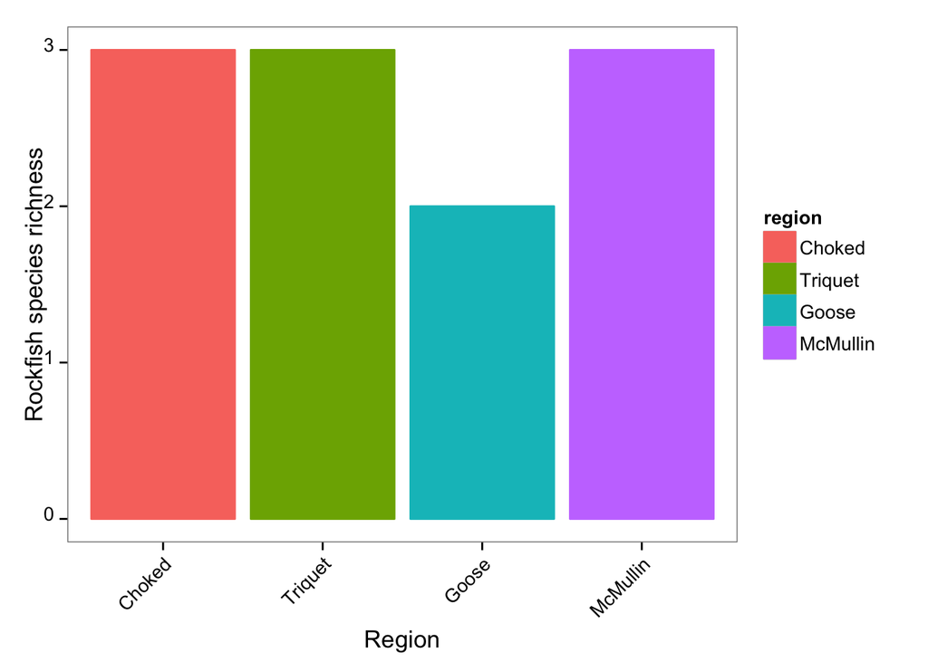

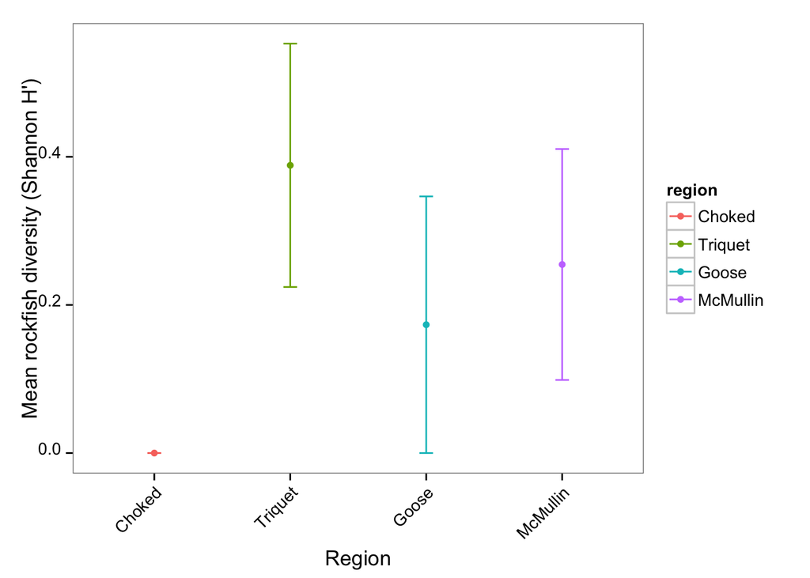

```r
write.csv(rockfish.summary.region, "summaries/rockfish.abund.region.2014.csv")
(rockfish.figs.regions   <- MakeFishFigures(rockfish.summary.region))
```

### Flat fish only

```r
(flatfish.summary.site   <- MakeFishSummary(fish.flat, site))
```

```
##   region         site mean.abund se.abund mean.H.prime se.H.prime n rich
## 1 Choked Choked Lower          1       NA            0         NA 1    1
```

```r
write.csv(flatfish.summary.site, "summaries/flatfish.abund.site.2014.csv")
# (flatfish.figs.site      <- MakeFishFigures(flatfish.summary.site))
(flatfish.summary.region <- MakeFishSummary(fish.flat))
```

```
##   region mean.abund se.abund mean.H.prime se.H.prime n rich
## 1 Choked          1       NA            0         NA 1    1
```

```r
write.csv(flatfish.summary.region, "summaries/flatfish.abund.region.2014.csv")
# (flatfish.figs.region    <- MakeFishFigures(flatfish.summary.region))
```

### Schooling fish only

```r
(schoolingfish.summary.site   <- MakeFishSummary(fish.schooling, site))
```

```
##     region            site mean.abund   se.abund mean.H.prime se.H.prime n
## 1   Choked    Choked Lower   1.666667  0.9189366   0.00000000 0.00000000 6
## 2   Choked Choked Sandspit   1.000000  0.0000000   0.00000000 0.00000000 2
## 3    Goose Goose Southeast  34.333333 15.4955191   0.18744505 0.18744505 3
## 4    Goose Goose Southwest   2.000000         NA   0.00000000         NA 1
## 5 McMullin  McMullin North  32.666667 17.0522074   0.02717014 0.02717014 3
## 6 McMullin  McMullin South  10.666667  9.6666667   0.00000000 0.00000000 3
## 7  Triquet     Triquet Bay  17.000000  9.0184995   0.13670544 0.13670544 3
## 8  Triquet   Triquet North  58.666667 45.6812629   0.49083628 0.24845342 3
##   rich
## 1    1
## 2    2
## 3    2
## 4    1
## 5    2
## 6    1
## 7    2
## 8    4
```

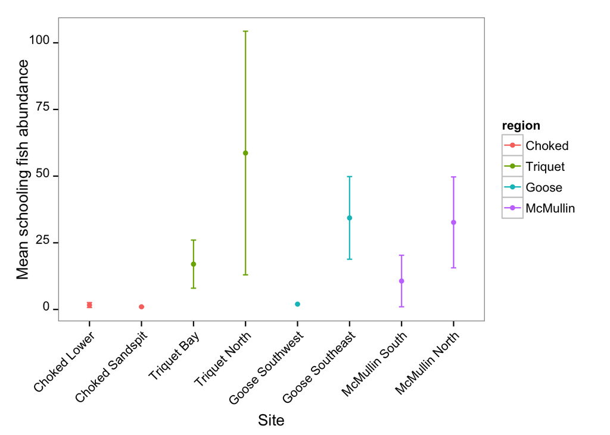

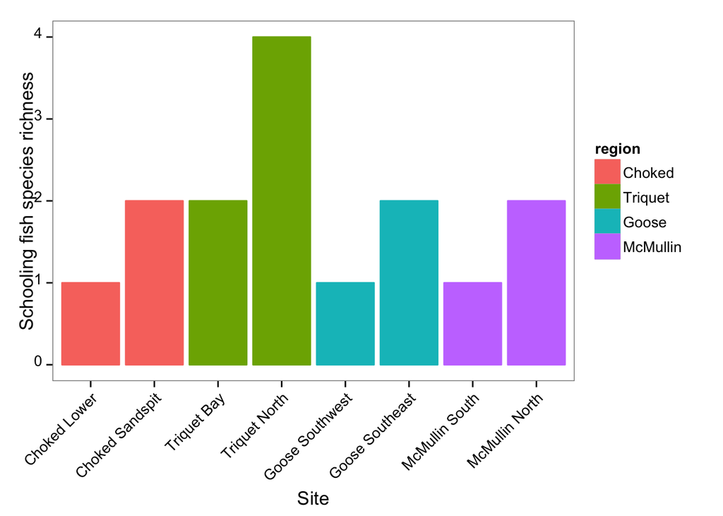

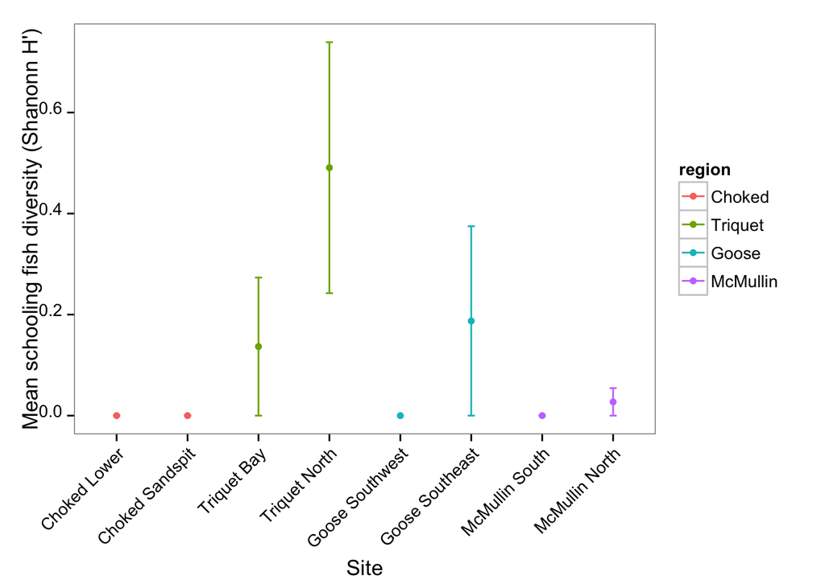

```r
write.csv(schoolingfish.summary.site, "summaries/schoolingfish.abund.site.2014.csv")
(schoolingfish.figs.site      <- MakeFishFigures(schoolingfish.summary.site))
```

```r
(schoolingfish.summary.region <- MakeFishSummary(fish.schooling))
```

```
##     region mean.abund   se.abund mean.H.prime se.H.prime n rich
## 1   Choked    1.50000  0.6813851   0.00000000 0.00000000 8    2
## 2    Goose   26.25000 13.6160139   0.14058379 0.14058379 4    3
## 3 McMullin   21.66667 10.0520866   0.01358507 0.01358507 6    2
## 4  Triquet   37.83333 22.8128862   0.31377086 0.14951230 6    4
```

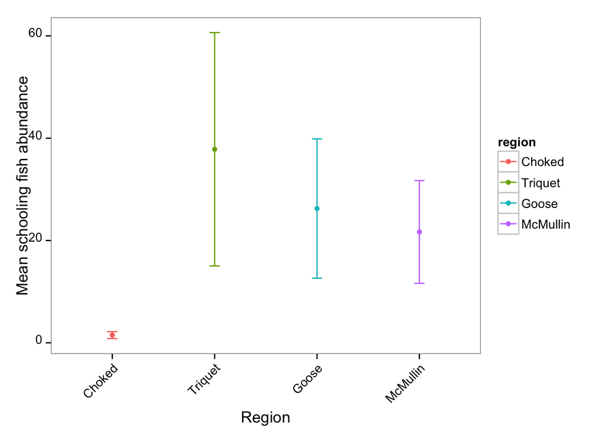

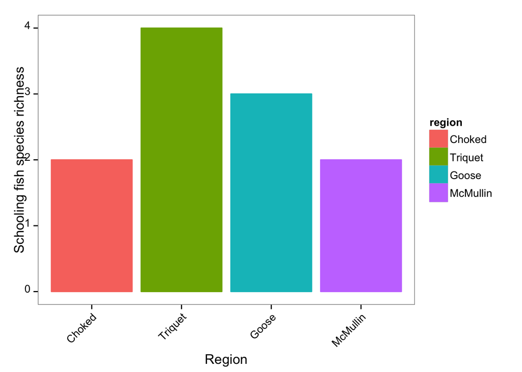

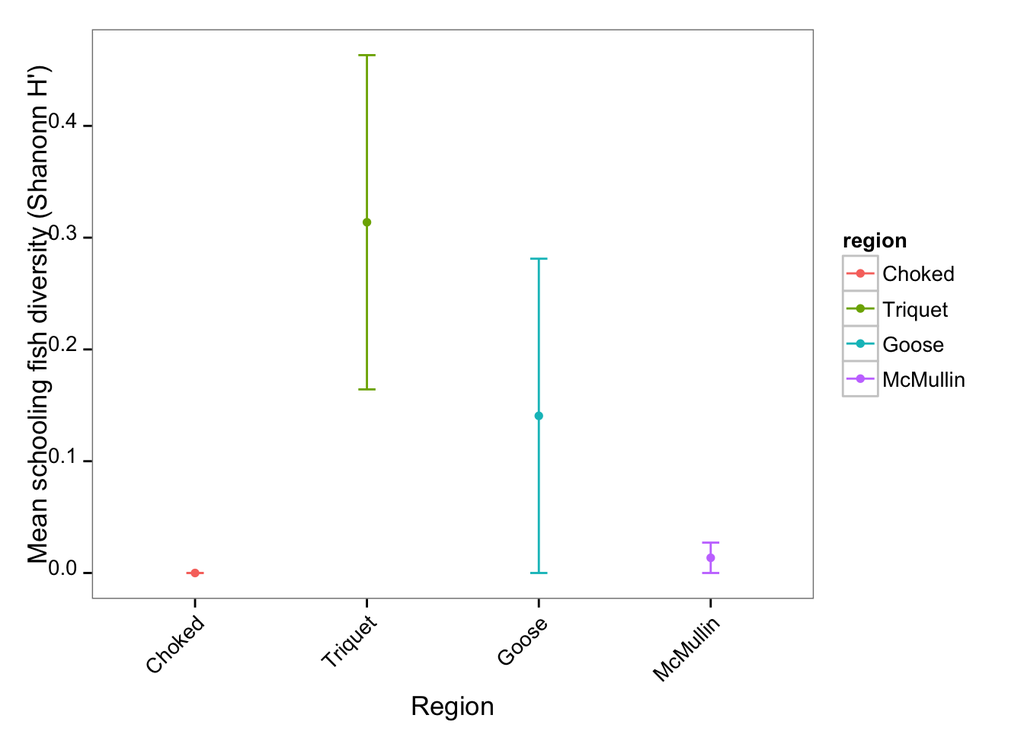

```r
write.csv(schoolingfish.summary.region, "summaries/schoolingfish.abund.region.2014.csv")
(schoolingfish.figs.region    <- MakeFishFigures(schoolingfish.summary.region))
```